# Relatedness tutorial

## What about population structure?

When there is population structure, the PLINK method described above will be biased and unreliable because it assumes individuals are drawn from a homogeneous population with known allele frequencies. Fortunately, there have been additional methods developed that work well under these conditions. The most well known is the [KING-Robust approach](https://www.kingrelatedness.com/manual.shtml) (link to [original paper](https://www.chen.kingrelatedness.com/publications/pdf/BI26_2867.pdf)). In general, you should choose the KING approach over the PLINK approach.

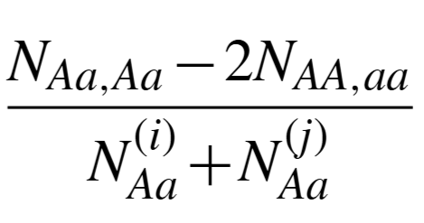

This approach is robust to population structure because it doesn’t require knowing population allele frequencies. However, it still requires that loci are in Hardy-Weinberg equilibrium.

from the manual:

```
Close relatives can be inferred fairly reliably based on the estimated kinship coefficients as shown in the following simple algorithm: an estimated kinship coefficient range >0.354, [0.177, 0.354], [0.0884, 0.177] and [0.0442, 0.0884] corresponds to duplicate/MZ twin, 1st-degree, 2nd-degree, and 3rd-degree relationships respectively. Relationship inference for more distant relationships is more challenging
```

## Calculating relatedness

Ok, so how do we actually analyze data? We’re going to follow the approach described by [Waples et al.](https://doi.org/10.1111/mec.14954) using NgsRelate.

This method is nice because:

1. It doesn’t require allele frequencies
2. Can work with low coverage data where genotypes don’t have to be hard called.

With the approach, we use three estimators to identify relatedness: KING-robust kinship estimator, R0, and R1. These are defined as follows, where we’re looking at the genotype for each of two individuals:

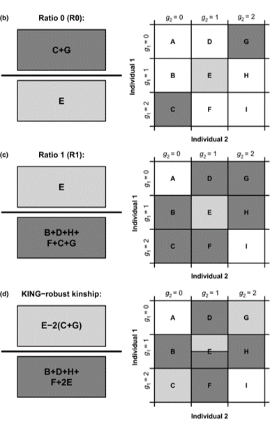

R0 is the proportion of sites where individuals have unique homozygous genotypes, scaled by the shared heterozygotes. This is a modified proportion of loci where IBS is 0, and is robust to ascertainment bias.

Specifically, we’re interested in the relationship between [R1, R0] and [R1, KING-robust kinship]. The rationale here is that each of the estimators, and the two relationships, are quantifying a unique aspect of relatedness and, are non-overlapping in their expectations for close familial relationships. So we can use the distributions from both relationships to robustly infer relatedness.

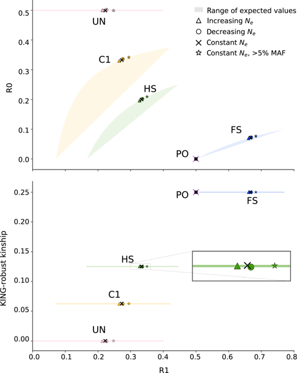

For example, the KING estimator cannot distinguish parent-offspring from full sibs. However, R0 and R1 can. This is because R0 is looking at the number of unique homozygotes for each individual and a parent offspring pair must always share one allele; R0 will be ~0 for parent-offspring and > 0 for full sibs. Similarly, R1 will be higher for full sibs than parent offspring.

### ngsrelate

We will use NgsRelate to calculate R0, R1, and the KING estimator. See the [NgsRelate paper here](https://academic.oup.com/gigascience/article/8/5/giz034/5481763).

This program can calculate a ton of different relatedness estimators and can handle genotype likelihoods or a vcf, which means it can handle low coverage data. For our example, we will use a vcf, but see the website for how to use likelihoods.

You can find `whales.vcf.gz` in the [git repo](https://github.com/rsbrennan-NOAA/relatedness_tutorial).

The command is straight forward:

```bash
ngsrelate -h  whales.vcf.gz -T GT -c 1 -O relatedness.res
```

Note that `-T GT` says we’re using genotypes and `-c 1` means we’ve already called these genotypes.

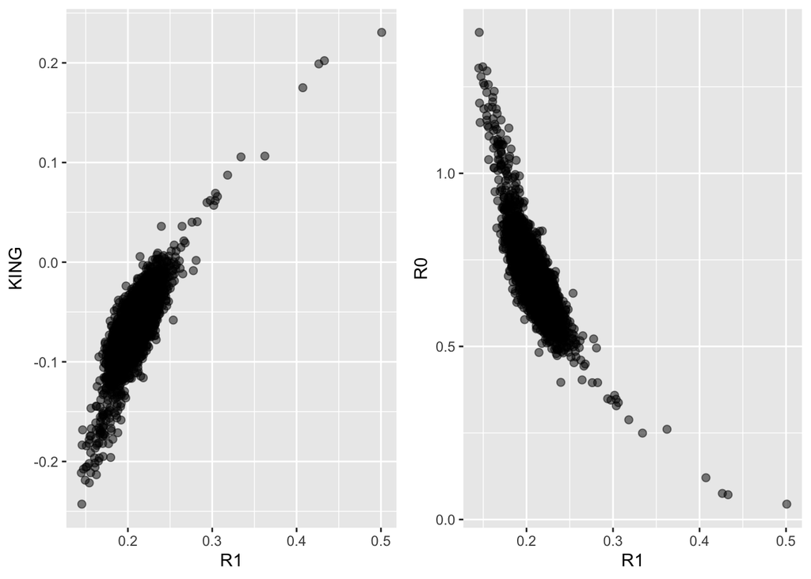

```r
library(ggplot2)
library(ggpubr)

dat <- read.table("relatedness.res", header=T)

R1_KING <- ggplot(dat, aes(x=R1, y=KING)) +
              geom_point(alpha=0.5, size=2)

R1_R0 <- ggplot(dat, aes(x=R1, y=R0)) +
              geom_point(alpha=0.5, size=2)

ggarrange(R1_KING, R1_R0)
```

You’ll notice that we have a bunch of negative values for our KING estimator and values > 0.5 for R0. This means that these individuals are less related than expected (i.e., maybe population structure is present). For our purposes, we don’t care about these unrelated individuals and can focus only on individuals with R0 < 0.5 and KING > 0.

And lets color these by the range KING gives for each relationship:

```
  Close relatives can be inferred fairly reliably based on the estimated kinship coefficients as shown in the following simple algorithm: an estimated kinship coefficient range >0.354, [0.177, 0.354], [0.0884, 0.177] and [0.0442, 0.0884] corresponds to duplicate/MZ twin, 1st-degree, 2nd-degree, and 3rd-degree relationships respectively. Relationship inference for more distant relationships is more challenging
```

So we will consider anything beyond a 3rd degree relative (cousin) unrelated.

```r
library(tidyverse)
```

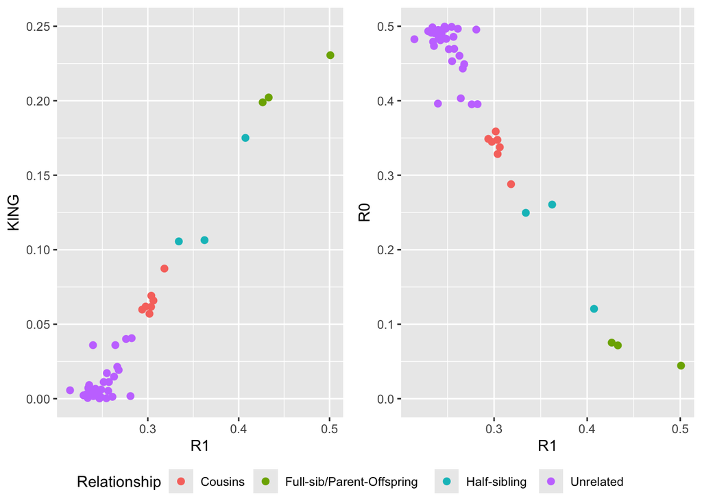

```r
dat <- dat %>%
  mutate(relationship = case_when(
    KING > 0.354 ~ "Duplicate/MZ twin",
    KING >= 0.177 & KING <= 0.354 ~ "Full-sib/Parent-Offspring",
    KING >= 0.0884 & KING < 0.177 ~ "Half-sibling",
    KING >= 0.0442 & KING < 0.0884 ~ "Cousins",
    KING < 0.0442 ~ "Unrelated",
    TRUE ~ "Other"
  ))

# then drop the points we don't want:
filter_dat <- dat %>%
  filter(R0 < 0.5, KING > 0)

R1_KING_filtered <- ggplot(filter_dat, aes(x = R1, y = KING, color = relationship)) +
                      geom_point(size = 2) +
                      ylim(0, 0.25) +
                      labs(color = "Relationship")

# Plot R1 vs R0 with relationship colors
R1_R0_filtered <- ggplot(filter_dat, aes(x = R1, y = R0, color = relationship)) +
                    geom_point(size = 2) +
                    ylim(0, 0.5) +
                    labs(color = "Relationship")

ggarrange(R1_KING_filtered, R1_R0_filtered, common.legend=T, legend="bottom")
```

How then do we tell the Full-sibs/parent-offspring apart? Remember that we can use R0. We expect parent-offspring pairs to be ~0 and full-sibs to be > 0.

Because we’re elevated above 0, these individuals are probably siblings, rather than parent offspring.

```r
table(dat$relationship)
```

```
##
##                   Cousins Full-sib/Parent-Offspring              Half-sibling
##                         7                         3                         3
##                 Unrelated
##                      2615
```